# Medic Mobile Vaccine Effectiveness Worksheet

# Synopsis

The purpose of this worksheet is to estimate the effectiveness of childhood vaccination programs on a population.

# Instructions

Every time you see a sentence in boldface, go to the R markdown source document and enter the requested value.

# Software Versions Tested

- Mac OS X Mavericks
- Wine 1.6.1, packaged with WineBottler
- Spectrum 4.7, includes LiST, DemProj and AIM
- RStudio 0.98 with knitr 1.5

# Preparation

**What is the name of the country?**

```r
country.name <- "Kenya"
```

**What is the first year you will be modeling an increase in vaccine coverage? Must be the current year or later.**

```r
first.anc.year <- 2015
```

**How many children will the program serve in 2015?**

```r
n.child.covered <- 5000
```

You are embarking on vaccine projection for Kenya. The year you want to model an increase in coverage is 2015.

# Initialize Spectrum

Launch Spectrum. (If this is your first time, proceed to the next step now. If this is not your first time, make sure all your previous projection are closed: in the *Home* tab, select *Close → All Projections*.)

Click *New* or *New projection*.

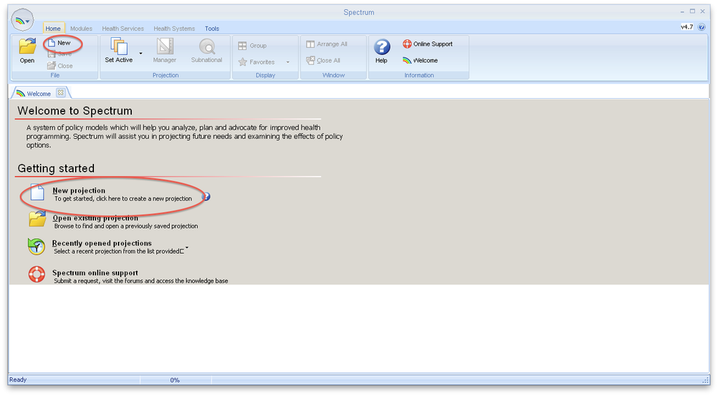

In the *New* dialog, under “Set a name…”, set the name for this projection. Make it descriptive of the country, locale and intervention.

Under “Set year boundaries…”, enter a first year that is at least a full year before the start of the intervention.

In the “Activate modules for use in your projection” area, check the following three boxes.

1. *Demographic Projection (DemProj)*
2. *AIDS (AIM)*
3. *Lives Saved Tool (LiST)*

In the “Select a country from which to retrieve demographic and other default data”, click *Country data* and select the country corresponding to 1b. Make sure DemProj, AIM, and LiST are checked (they should already be).

Click *Ok*.

# Determine Children in Country

Click on the *Modules* tab in the main window.

Click on the *DemProj* module.

Select *Results → Age Groups → All Age Groups*. You should see a popup titled *Configure - All Age Groups*.

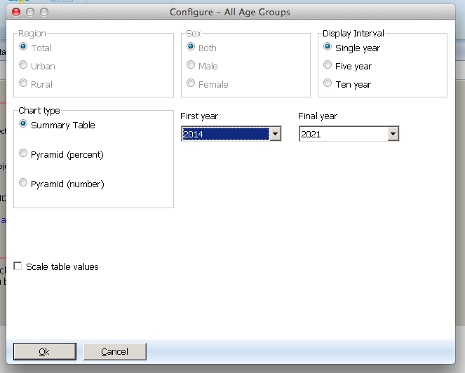

Click *OK*.

You should now see a tab titled 'Population by age and sex' with a population table in it. There seems to be a bug in this Spectrum version where even if Single year is selected ages are given in five year increments. When this bug is fixed, the 0-1 age group should be used.

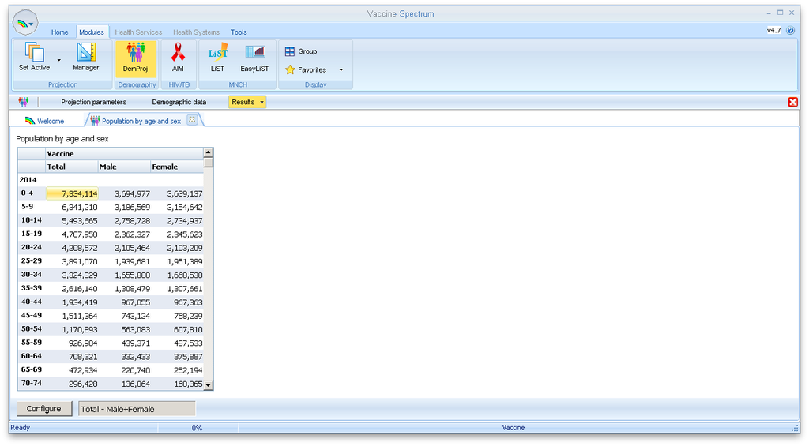

```r
n.child.zero_to_four <- 7334114
```

What we are actually interested in is the children age 0-1. Until Spectrum provides this information directly, we can approximate by dividing the 0-4 group by 5. This has obvious inaccuracies; if a better method of obtaining this population size is available it should be used.

Children 0-1:

*1.4668 × 10<sup>6</sup>*

# Scale up Vaccines in LiST

Make sure you’re in the *Modules* tab. Select the *LiST* module.

Select *Coverage*. In the dialog, select the *Vaccines* tab. You’ll see nationally averaged coverage rates already populated in the table. Look at the year in the table corresponding to 2015.

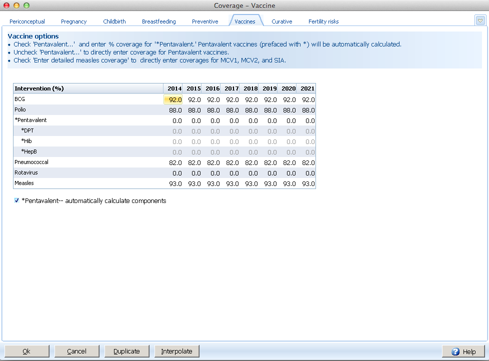

**What is the coverage rate shown for Polio in 2015?**

```r
baseline.polio.coverage.rate <- 88
```

**What is the coverage rate shown for DTP in 2015?**

```r
baseline.dtp.coverage.rate <- 0
```

**What is the coverage rate shown for Measles in 2015?**

```r
baseline.measles.coverage.rate <- 93
```

In order to compute the new vaccine rates after the intervention, we'll assume that all children in the country not affected by the intervention are subject to the national average rate, and that all children in the intervention have a 100% coverage rate for a given vaccine.

To compute this we use the formula

\[ \frac{\text{default coverage rate} \times (N\text{ all 0-1 children} - N\text{ children covered by this program}) + N\text{ children covered by this program}}{N\text{ 0-1 children}}, \]

New Polio Coverage Rate:

*88.3*

New DTP Coverage Rate:

*0.3*

New Measles Coverage Rate:

*93.3*

Now update the coverage rate for those three vaccines in 2015. To do so click the appropriate box and update the value. To update DPT you may need to uncheck the *Pentavalent– automatically calculate components* checkbox.

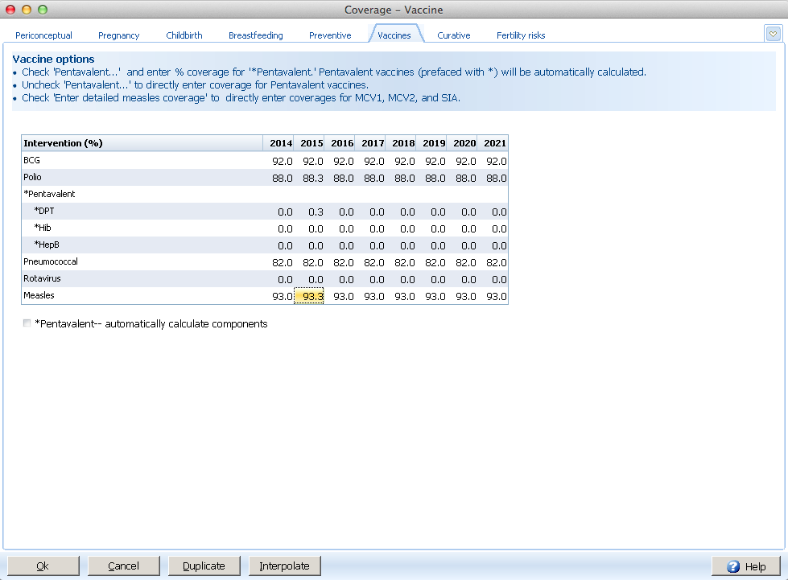

Click *Ok* to save changes and exit the dialog.

Now to compute lives saved. Click *Results → Child → Additional deaths prevented in children under five years of age relative to impact year*. In the dialog, select *Table* and hit *Ok*. You should see a table like this.

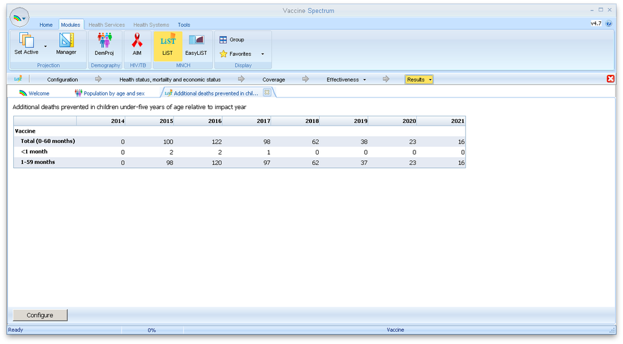

Zero or negative numbers mean you haven't prevented any deaths. Positive numbers tell you how many lives you've saved per year. The totals across all age groups appear in the first line of the table.